# Oregon Referee Report

## Breakdown of Officials

We have a substantial number of referees under the age of 20 with solid representation of women, however the data suggests a substantial attrition with women disproportionately dropping out.

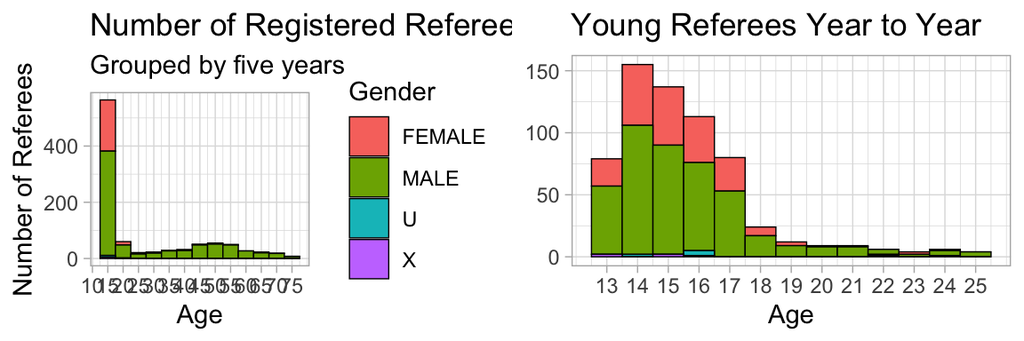

## Locations of Registered Officials

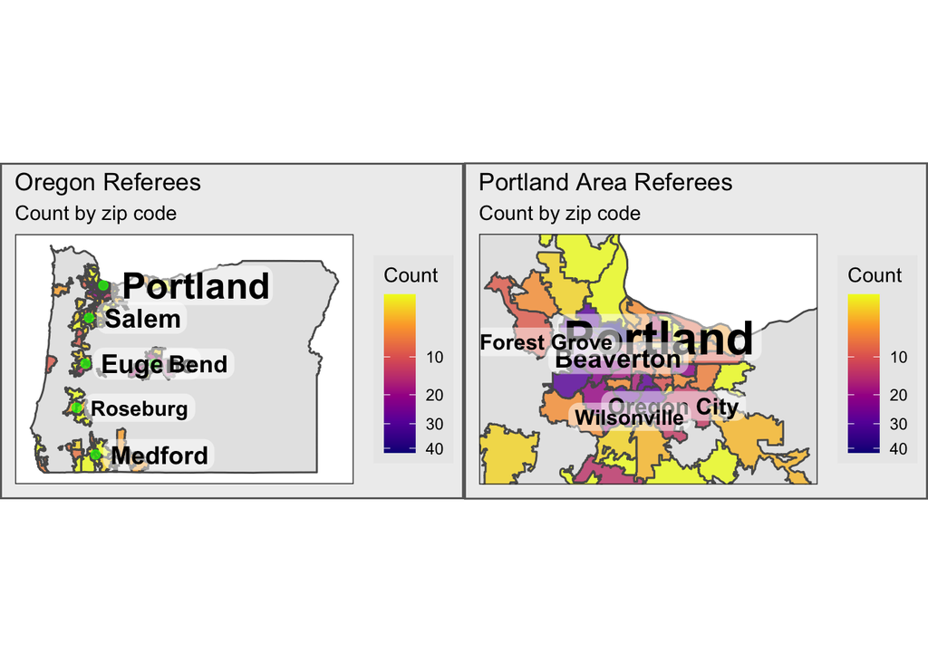

### Mentors and Instructors

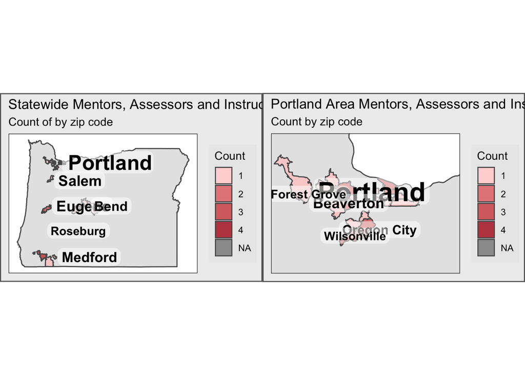

# Oldest and Youngest

Here are the oldest and youngest referees.

Twenty Oldest Referees

| Full Name | Born | Age | Referee |
| --- | --- | --- | --- |
| Richard Horner | Feb 1946 | 76 | Regional Emeritus |
| BOB HUGHES | Aug 1945 | 76 | Grassroots |
| Jon Wittwer | Dec 1945 | 76 | Grassroots |
| David Rouse | Aug 1947 | 74 | Grassroots |
| Kathy Gersztyn | Dec 1947 | 74 | Grassroots |
| John Hanna | Dec 1947 | 74 | Grassroots |
| David Nordstrom | Oct 1948 | 73 | Grassroots |
| Keith Cubic | Jul 1948 | 73 | Grassroots |
| Jonathan Siegle | May 1949 | 72 | Regional Emeritus |
| Patrick Duffy | Dec 1949 | 72 | Regional |
| Dana Stone | Feb 1950 | 72 | Grassroots |
| James Lakehomer | Feb 1950 | 72 | Regional Emeritus |
| Manuel Palacio | Mar 1949 | 72 | Grassroots |
| Jerry Gompers | Jan 1951 | 71 | Regional Emeritus |
| keith ericson | Jun 1950 | 71 | Grassroots |
| Cindy Wilgus | Nov 1951 | 70 | Grassroots |
| Xavier Valdes | Mar 1952 | 70 | Grassroots |
| James Culbert | Jan 1953 | 69 | Grassroots |
| Patrick Bowman | Jul 1952 | 69 | Regional Emeritus |
| PATRICK EVOY | Dec 1952 | 69 | Regional Emeritus |

Twenty Youngest Referees

| Full Name | Born | Age |
| --- | --- | --- |
| Cameron Carter | Apr 2008 | 13 |
| Holly Beltramini | Mar 2008 | 13 |
| Kelan Murray | Mar 2008 | 13 |
| Trevor Gorski | Mar 2008 | 13 |
| Thaddeus Suckow | May 2008 | 13 |
| Alexander Monroy | Jun 2008 | 13 |
| Brooke Wesener | May 2008 | 13 |
| Sydney McCornack | Jul 2008 | 13 |
| Lexie Wilkie | Apr 2008 | 13 |
| Sam Schecter | Mar 2008 | 13 |
| Chloe Brown | Mar 2008 | 13 |
| Lucy Hays | Apr 2008 | 13 |
| Olivia Hays | Apr 2008 | 13 |
| Jonathan Ayers | Mar 2008 | 13 |
| Asher Parnell | Jul 2008 | 13 |
| Reese Heffler | May 2008 | 13 |
| Jackson Trautman | Jul 2008 | 13 |
| Greta Dazer | Jul 2008 | 13 |
| Luke Hancock | May 2008 | 13 |
| Sophia Montez | Jun 2008 | 13 |

## Year Over Year Analysis

I don’t know if this is valid but I compared the registered referees from mid-2021 to the current list.

In 2021, a total of 1,352 officials registered.

In 2022, so far 976 officials have registered.

510 or 52% have at least partially renewed their registrations.

This year, there are *466* officials who are either new or did not register in 2021.

In analyzing the attrition by gender, it turns out a substantial number of referees are registered without a gender (188). This seems to be some error in data collection since this phenomenon is not reflected in 2022 data.

So this graph is filtered for referees registered with a gender.

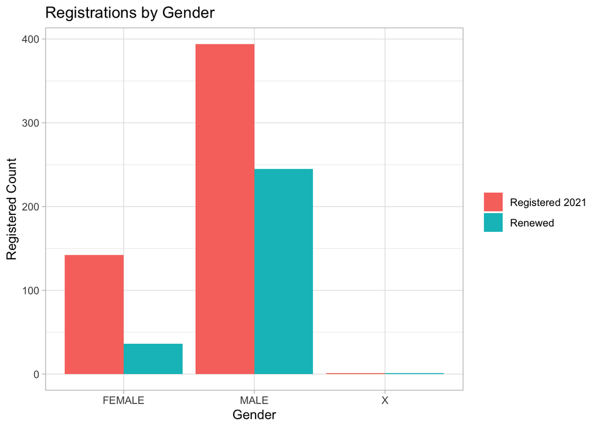

Dividing registrations into age groups you can see the biggest drop off in re-registering seems to be referees between 15 and 18 years old.

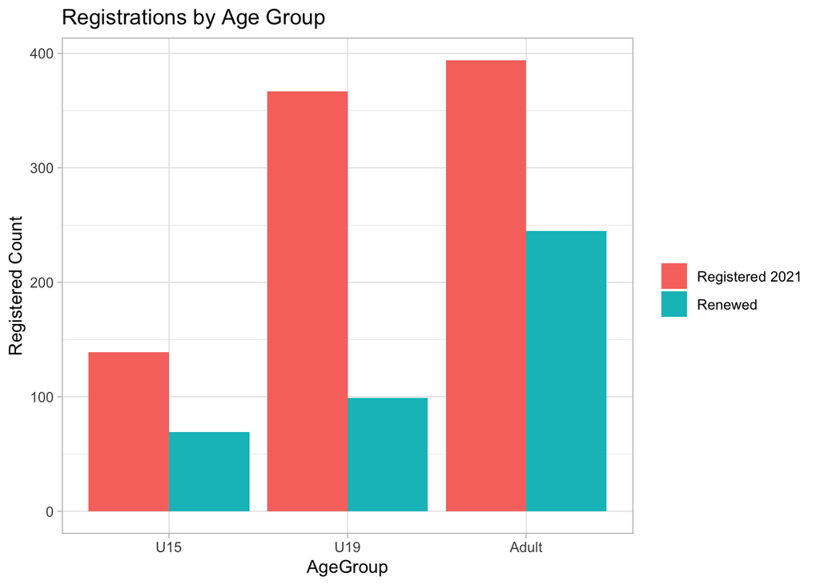